# La probabilidad de ganar un punto en bádminton. Un análisis de los patrones de golpeo.

Autores/as

Alonso González Romero

Daniel López Paredes

Alba Martínez de la Hermosa

Fecha de publicación

8 de abril de 2026

# 1 Importación de librerías necesarias

# 2 Introducción

La ganancia de puntos en los deportes de raqueta se consigue enviando la pelota o el volante a una zona de la pista a la que el contrincante no es capaz de llegar, o llega muy forzado, para devolver el golpe. En bádminton, los partidos se ganan al mejor de 3 **sets**. Para ganar un set se deben conseguir 21 **puntos** con una distancia mínima de 2 con respecto al contrario. En caso de una distancia menor, la puntuación por set puede alcanzar un máximo de 30 puntos.

Para sumar dichos puntos al marcador se deben ganar los rallies. Un **rally** es la secuencia completa desde que un jugador saca hasta que el volante toca el suelo, va fuera de la pista o acaba en la red. Cada vez que uno de los contrincantes saca, comienza un nuevo rally. Este está compuesto por intercambios entre los jugadores, llamados **stroke**. En otras palabras, un stroke ocurre cada vez que el volante sobrepasa la red.

La pista se divide en dos campos a cada lado de la red, cada uno de los cuales se estructura en **12 zonas de golpeo**. Las zonas de juego son la base para la planificación de estrategias de juego; a partir de ellas surgen preguntas como:

- ¿Qué zonas son las más habituales para golpear?
- ¿Qué secuencias (intercambios de una zona a otra entre los dos jugadores) son las más frecuentes?
- ¿Cuáles de esas zonas y/o secuencias tienen mayor probabilidad de llevar a la consecución del punto?
- ¿Qué zonas y/o secuencias son el punto fuerte y punto débil propio y del rival?

Para resolver estas preguntas, en el presente análisis se utilizan varios datos de partidos de Carolina Marín. Se estudiarán las zonas y secuencias de golpeo con el objetivo de conocer la probabilidad de ganar un punto de dicha jugadora.

# 3 Procedimiento del análisis

# 4 Importación del dataset. Análisis exploratorio inicial.

A continuación, importamos el dataset con los datos de los partidos de Carolina Marín.

Antes de comenzar con el análisis, es importante conocer el significado de cada una de las variables del dataset. Para ello, se presenta el siguiente diccionario de datos.

Tabla 1: Diccionario de variables del dataset

| Variable | Descripción | Tipo de Dato | Ejemplo del dataset |
| --- | --- | --- | --- |
| **Match** | Identificador de los jugadores que disputan el partido. | `object` (String) | `Carolina Marin-Li Xuerui` |
| **Set** | Número del set en juego. | `int64` (Entero) | `1` |
| **Rally** | Número de punto dentro de un set en juego. | `int64` (Entero) | `0` |
| **Stroke** | Número secuencial del golpe dentro del punto (Rally). | `int64` (Entero) | `1`, `2`, `3`… |
| **X** | Coordenada horizontal desde donde se golpea/aterriza el volante. | `int64` / `float64` | `10`, `-14` |
| **Y** | Coordenada vertical desde donde se golpea/aterriza el volante. | `int64` / `float64` | `55`, `-54` |
| **Zone** | Código identificador de la zona de la pista del impacto. | `int64` (Categórico) | `12`, `5`, `67` |
| **Jugador del golpeo** | Nombre de la jugadora que ejecuta ese golpe específico. | `object` (String) | `Li Xuerui` |
| **Player1** | Nombre de la jugadora asignada como Jugadora 1. | `object` (String) | `Carolina Marin` |
| **Player2** | Nombre de la jugadora asignada como Jugadora 2. | `object` (String) | `Li Xuerui` |
| **Player 1 Score** | Puntuación de la Jugadora 1 en el momento del golpe. | `int64` (Entero) | `0` |
| **Player 2 Score** | Puntuación de la Jugadora 2 en el momento del golpe. | `int64` (Entero) | `0` |
| **WR Player1** | *World Ranking* (Clasificación Mundial) de la Jugadora 1. | `int64` (Entero) | `1` |
| **WR Player2** | *World Ranking* (Clasificación Mundial) de la Jugadora 2. | `int64` (Entero) | `3` |

Tras conocer el significado de cada una de las variables, vamos a hacer un análisis básico de comprobación de calidad y reconocimiento de los datos.

**Código**

```python
# 1. Primeras filas
print("--- Primeras Filas ---")
print(datos_badminton.head())

# 2. Información de columnas: Nombre, Tipo de Dato y Nulos
print("\n--- Estructura y Nulos ---")
resumen_columnas = pd.DataFrame({
    'Columna': datos_badminton.columns,
    'Tipo': datos_badminton.dtypes.values,
    'Nulos': datos_badminton.isnull().sum().values
})
print(resumen_columnas)

# 3. Duplicados
print(f"\nTotal de filas duplicadas: {datos_badminton.duplicated().sum()}")
```

```
--- Primeras Filas ---
                      Match  Set  Rally  Stroke   X   Y Zone  \
0  Carolina Marin-Li Xuerui    1      0       1  -1 -26    7
1  Carolina Marin-Li Xuerui    1      0       2  10  55   12
2  Carolina Marin-Li Xuerui    1      0       3 -10 -53   12
3  Carolina Marin-Li Xuerui    1      0       4 -14  39    5
4  Carolina Marin-Li Xuerui    1      0       5 -13 -54   12

  Jugador del golpeo         Player1    Player2  Player 1 Score  \
0          Li Xuerui  Carolina Marin  Li Xuerui               0
1     Carolina Marin  Carolina Marin  Li Xuerui               0
2          Li Xuerui  Carolina Marin  Li Xuerui               0
3     Carolina Marin  Carolina Marin  Li Xuerui               0
4          Li Xuerui  Carolina Marin  Li Xuerui               0

```

[output cut: 25 more lines]

Se observan los tipos de dato que hay en cada columna y se comprueba que no hay valores faltantes ni duplicados de ningún set, rally, stroke o punto. Por tanto, los datos se presentan limpios para su tratamiento.

## 4.1 Estadísticas básicas de los partidos

Conociendo las características principales del dataset y lo que significa cada una de las variables, se procede a obtener los resultados de los partidos que ha jugado Carolina Marín.

Para ello, primero calculamos los resultados de cada set:

**Código**

[figure not shown]

[figure not shown]

[figure not shown]

[figure not shown]

[figure not shown]

```python
# Obtener la puntuación final de cada jugadora por cada set
resumen_sets = datos_badminton.groupby(['Match', 'Set', 'Player1', 'Player2', 'WR Player1', 'WR Player2'])[['Player 1 Score', 'Player 2 Score']].max().reset_index()

for partido in resumen_sets['Match'].unique():
    generar_rotulo_tv_definitivo(resumen_sets, partido)
```

Viendo los resultados, sólo una jugadora ganó un set contra Carolina Marín, siendo el único partido que llegó a 3 sets. En el resto de partidos, Carolina Marín ganó los 2 sets disputados.

La ganadora de todos los partidos fue Carolina Marín.

# 5 Estadísticas de las zonas de golpeo

Habiendo realizado un vistazo general a los partidos de la jugadora española, se procede a analizar en profundidad el juego obteniendo las estadísticas de las zonas y las secuencias de golpeo.

Antes de comenzar, el siguiente código muestra un campograma de una pista de badminton. Más adelante pintaremos sobre él las zonas de golpeo más frecuentes y distintas estadísticas.

**Código**

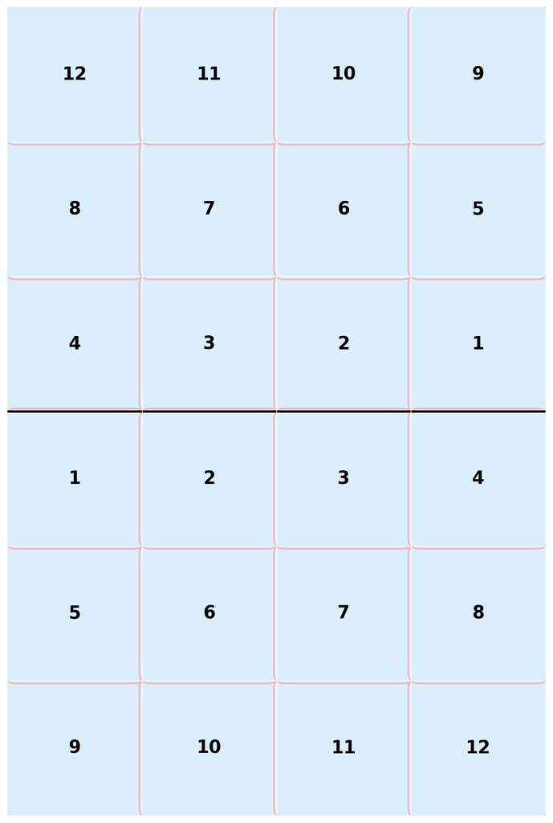

```python
import matplotlib.patches as patches
from matplotlib.colors import Normalize

def dibujar_mapa_badminton_zonas(valores_superior=None, valores_inferior=None, mostrar_porcentaje=True, cmap=plt.cm.Blues):
    fig, ax = plt.subplots(figsize=(8, 11))

    ancho = 4
    alto_mitad = 3
    alto_total = alto_mitad * 2
    color_fondo = '#dbeeff'
    color_borde = '#f4b6b6'

    ax.set_xlim(0, ancho)
    ax.set_ylim(0, alto_total)
    ax.set_aspect('equal')
    ax.axis('off')

    # Fondo de la pista completa
    pista = patches.Rectangle((0, 0), ancho, alto_total, facecolor=color_fondo, edgecolor='none')
    ax.add_patch(pista)

    # Contorno exterior y red central
    ax.add_patch(patches.Rectangle((0, 0), ancho, alto_total, fill=False, edgecolor='gray', linewidth=1.8))
    ax.plot([0, ancho], [alto_mitad, alto_mitad], color='black', linewidth=2.2)

    # Zonas 4x3 en cada mitad
    zona_ancho = ancho / 4
    zona_alto = alto_mitad / 3

    def preparar_matriz(valores):
        if valores is None:
            return None
        matriz = np.asarray(valores, dtype=float)
        if matriz.shape != (3, 4):
            raise ValueError('Cada mitad debe tener una matriz de 3 filas x 4 columnas.')
        return matriz

    valores_superior = preparar_matriz(valores_superior)
    valores_inferior = preparar_matriz(valores_inferior)

    todas_las_medidas = []
    for matriz in [valores_superior, valores_inferior]:
        if matriz is not None:
            todas_las_medidas.append(matriz.ravel())

    if todas_las_medidas:
        medidas = np.concatenate(todas_las_medidas)
        medidas = medidas[~np.isnan(medidas)]
        minimo = float(np.min(medidas))
        maximo = float(np.max(medidas))
        normalizador = Normalize(vmin=minimo, vmax=maximo if maximo > minimo else minimo + 1)
    else:
        normalizador = None

    def dibujar_mitad(origen_y, etiquetas, valores=None):
        for fila in range(3):
            for columna in range(4):
                x = columna * zona_ancho
                y = origen_y + fila * zona_alto

                valor = None if valores is None else valores[fila, columna]
                if normalizador is not None and valor is not None and not np.isnan(valor):
                    color_relleno = cmap(0.20 + 0.70 * normalizador(valor))
                    alpha = 0.95
                else:
                    color_relleno = color_fondo
                    alpha = 1.0

                zona = patches.FancyBboxPatch(
                    (x, y),
                    zona_ancho,
                    zona_alto,
                    boxstyle='round,pad=0.02,rounding_size=0.08',
                    facecolor=color_relleno,
                    edgecolor=color_borde,
                    linewidth=1.6,
                    alpha=alpha,
                )
                ax.add_patch(zona)

                etiqueta = etiquetas[fila][columna]
                color_texto = 'white' if (normalizador is not None and valor is not None and not np.isnan(valor) and normalizador(valor) > 0.55) else 'black'
                ax.text(
                    x + zona_ancho / 2,
                    y + zona_alto / 2 + (0.10 if mostrar_porcentaje and valor is not None else 0.0),
                    str(etiqueta),
                    ha='center',
                    va='center',
                    fontsize=17,
                    fontweight='bold',
                    color=color_texto,
                )

                if mostrar_porcentaje and valor is not None and not np.isnan(valor):
                    valor_mostrado = valor
                    if abs(valor_mostrado) <= 1:
                        valor_mostrado *= 100
                    ax.text(
                        x + zona_ancho / 2,
                        y + zona_alto / 2 - 0.20,
                        f'{valor_mostrado:.1f}%',
                        ha='center',
                        va='center',
                        fontsize=9,
                        fontweight='normal',
                        color=color_texto,
                    )

    # Mitad superior: numeración de 12 a 1 empezando en la esquina superior derecha
    etiquetas_superiores = [
        [4,3,2,1],
        [8,7,6,5],
        [12,11,10,9],
    ]

    # Mitad inferior: numeración de 1 a 12 empezando en la esquina superior derecha
    etiquetas_inferiores = [
        [9,10,11,12],
        [5,6,7,8],
        [1,2,3,4],
    ]

    dibujar_mitad(alto_mitad, etiquetas_superiores, valores_superior)
    dibujar_mitad(0, etiquetas_inferiores, valores_inferior)

    # Líneas interiores de cada mitad
    for x in [1, 2, 3]:
        ax.plot([x, x], [0, alto_total], color='white', linewidth=1.1, alpha=0.6)

    for y in [1, 2, 4, 5]:
        ax.plot([0, ancho], [y, y], color='white', linewidth=1.1, alpha=0.6)

    plt.tight_layout()
    plt.show()

dibujar_mapa_badminton_zonas()
```

En primer lugar, se hace un recuento de las zonas de golpeo más frecuentes en el total de los partidos, sin hacer distinción por el momento entre jugadoras.

**Código**

```python
frecuencia_zonas_golpeo = datos_badminton['Zone'].value_counts().reset_index()
frecuencia_zonas_golpeo.columns = ['Zonas de golpeo', 'Frecuencia']

print("--- Zonas de golpeo más habituales en los partidos ---")
print(frecuencia_zonas_golpeo.head(10).to_string(index=False))
```

```
--- Zonas de golpeo más habituales en los partidos ---
Zonas de golpeo  Frecuencia
             12         594
              1         529
              4         512
              9         478
              5         306
              6         278
              8         270
              7         262
            Red         133
              2          92
```

En la siguiente tabla se observan las zonas más frecuentes de golpeo por cada partido.

**Código**

```python
frecuencias_golpeo_partido = datos_badminton.groupby(['Match'], sort=False)['Zone'].value_counts().reset_index()
frecuencias_golpeo_partido.columns = ['Partido', 'Zonas de golpeo', 'Frecuencia']

print("--- Zonas de golpeo más habituales en cada partido ---")
print(frecuencias_golpeo_partido.head(10).to_string(index=False))
```

```
--- Zonas de golpeo más habituales en cada partido ---
                        Partido Zonas de golpeo  Frecuencia
    Carolina Marin-P. V. Sindhu               1         188
    Carolina Marin-P. V. Sindhu              12         185
    Carolina Marin-P. V. Sindhu               4         169
       Carolina Marin-Li Xuerui              12         140
       Carolina Marin-Li Xuerui               9         126
    Carolina Marin-P. V. Sindhu               9         125
    Carolina Marin-Sung Ji Hyun               4         112
       Carolina Marin-Li Xuerui               1         110
Carolina Marin-Line Kjaersfeldt              12         109
       Carolina Marin-Li Xuerui               4         103
```

Teniendo ya las estadísticas generales, se observan las zonas más frecuentes para Carolina. Primeramente, se hace un conteo de todos los partidos. Este mismo conteo se presenta dividido por partidos inmediatamente después.

**Código**

```python
frecuencia_zonas_golpeo_Carolina = datos_badminton.groupby(['Jugador del golpeo'])['Zone'].value_counts().reset_index()
frecuencia_zonas_golpeo_Carolina.columns = ['Jugadora', 'Zonas de golpeo', 'Frecuencia']

print("--- Zonas de golpeo más habituales de Carolina Marín en los partidos ---")
print(frecuencia_zonas_golpeo_Carolina.head(10).to_string(index=False))
```

```
--- Zonas de golpeo más habituales de Carolina Marín en los partidos ---
      Jugadora Zonas de golpeo  Frecuencia
Carolina Marin               9         287
Carolina Marin              12         277
Carolina Marin               1         275
Carolina Marin               4         251
Carolina Marin               7         150
Carolina Marin               6         140
Carolina Marin               5         135
Carolina Marin               8         122
Carolina Marin             Red          71
Carolina Marin             Out          41
```

**Código**

```python
datos_Carolina = datos_badminton[datos_badminton['Jugador del golpeo'] == 'Carolina Marin']

frecuencias_golpeo_partido_Carolina = datos_Carolina.groupby(['Match', 'Jugador del golpeo'], sort=False)['Zone'].value_counts().reset_index()
frecuencias_golpeo_partido_Carolina.columns = ['Partido', 'Jugadora', 'Zonas de golpeo', 'Frecuencia']

print("--- Zonas de golpeo más habituales en cada partido ---")
print(frecuencias_golpeo_partido_Carolina.head(10).to_string(index=False))
```

```
--- Zonas de golpeo más habituales en cada partido ---
                        Partido       Jugadora Zonas de golpeo  Frecuencia
    Carolina Marin-P. V. Sindhu Carolina Marin               1         101
    Carolina Marin-P. V. Sindhu Carolina Marin               4          95
    Carolina Marin-P. V. Sindhu Carolina Marin              12          87
    Carolina Marin-P. V. Sindhu Carolina Marin               9          75
       Carolina Marin-Li Xuerui Carolina Marin              12          72
       Carolina Marin-Li Xuerui Carolina Marin               9          67
Carolina Marin-Line Kjaersfeldt Carolina Marin               9          58
       Carolina Marin-Li Xuerui Carolina Marin               4          53
       Carolina Marin-Li Xuerui Carolina Marin               1          52
Carolina Marin-Line Kjaersfeldt Carolina Marin              12          51
```

Después del conteo básico, es importante conocer cuál de esas zonas es la que con más probabilidad hará ganar el punto a Carolina. Para ello se observa cuál ha sido la zona final de cada rally y si en esa zona la puntuación de Carolina en la columna *Player 1 Score* ha aumentado en una unidad. Siguiendo con la misma dinámica, primero se presenta esta información para todos los partidos. Seguidamente, se divide por encuentros.

**Código**

```python
def analizar_zonas_y_puntos(df):
    df_temp = df.copy()

    # 1. Identificar el resultado de cada rally. Agrupar para saber el score final y la última zona de cada rally
    rallies = df_temp.groupby(['Match', 'Set', 'Rally'], sort=False).agg({
        'Player 1 Score': 'max',
        'Zone': list,  # Guardamos la secuencia de zonas
    }).reset_index()

    # 2. Determinar si Player1 ganó el punto (comparando con el rally anterior)
    rallies['Score_Previo_P1'] = rallies.groupby(['Match', 'Set'])['Player 1 Score'].shift(1).fillna(0)
    rallies['Gana_P1'] = rallies['Player 1 Score'] > rallies['Score_Previo_P1']

    # 3. Extraer la "Zona Final" de cada rally
    rallies['Zona_Final'] = rallies['Zone'].apply(lambda x: x[-1])

    # 4. Filtrar solo los rallies que ganó Player1
    rallies_ganados_p1 = rallies[rallies['Gana_P1'] == True]

    # 5. Contar cuántos puntos ganó P1 en cada zona final
    resumen_zonas = rallies_ganados_p1['Zona_Final'].value_counts().reset_index()
    resumen_zonas.columns = ['Zona', 'Puntos Ganados']

    # 6. Calcular efectividad: ¿Qué % de veces que el rally acaba en esa zona gana P1?
    total_por_zona = rallies['Zona_Final'].value_counts().reset_index()
    total_por_zona.columns = ['Zona', 'Total Rallies Finalizados']

    comparativa = resumen_zonas.merge(total_por_zona, on='Zona')
    comparativa['% Efectividad P1'] = (comparativa['Puntos Ganados'] / comparativa['Total Rallies Finalizados'] * 100).round(2)

    orden_columnas = ['Zona', 'Total Rallies Finalizados', 'Puntos Ganados', '% Efectividad P1']
    comparativa = comparativa[orden_columnas]

    return comparativa.sort_values(by='Puntos Ganados', ascending=False)

analisis_zonas = analizar_zonas_y_puntos(datos_badminton)
print("--- Relación de Zonas Finales y Puntos Ganados por Player1 ---")
print(analisis_zonas.to_string(index=False))
```

```
--- Relación de Zonas Finales y Puntos Ganados por Player1 ---
Zona  Total Rallies Finalizados  Puntos Ganados  % Efectividad P1
 Red                        133              71             53.38
 Out                         69              41             59.42
   1                         25              22             88.00
  12                         33              19             57.58
   9                         28              19             67.86
   5                         30              18             60.00
   8                         16              13             81.25
   4                         18              11             61.11
   6                          9               9            100.00
   7                          7               4             57.14
   3                          1               1            100.00
  10                          3               1             33.33
```

Tomando la fila de la zona 1 de ejemplo, se observa que 25 puntos (columna *Total Rallies Finalizados*) acabaron en la zona 1. De esos 25 puntos, 22 los ganó Carolina (columna *Puntos Ganados*), consiguiendo una efectividad (puntos ganados en esa zona / total de rallies finalizados en esa zona) del 88% en zona 1.

Poniendo la atención en “Out” se observa que 69 puntos la secuencia de golepos acaba fuera de la pista, de los cuales 41 los gana Carolina. Es decir, solamente en 28 de 69 ocasiones Carolina ha enviado fuera el volante en comparación con las 41 de sus rivales.

**Código**

```python
def analizar_zonas_y_puntos_partido(df):
    df_temp = df.copy()

    # 1. Identificar el resultado de cada rally
    rallies = df_temp.groupby(['Match', 'Set', 'Rally'], sort=False).agg({
        'Player 1 Score': 'max',
        'Zone': list,
    }).reset_index()

    # 2. Determinar si Player1 ganó el punto
    rallies['Score_Previo_P1'] = rallies.groupby(['Match', 'Set'])['Player 1 Score'].shift(1).fillna(0)
    rallies['Gana_P1'] = rallies['Player 1 Score'] > rallies['Score_Previo_P1']

    # 3. Extraer la "Zona Final" de cada rally
    rallies['Zona_Final'] = rallies['Zone'].apply(lambda x: x[-1])

    # 4. Puntos ganados por P1 por partido y zona. Agrupar por Match y Zona_Final
    resumen_zonas = rallies[rallies['Gana_P1'] == True].groupby(['Match', 'Zona_Final']).size().reset_index(name='Puntos Ganados')

    # 5. Total de veces que un rally terminó en esa zona (gane quien gane)
    total_por_zona = rallies.groupby(['Match', 'Zona_Final']).size().reset_index(name='Total Rallies Finalizados')

    # 6. Unir los dos conteos usando las columnas que tienen en común
    comparativa = resumen_zonas.merge(total_por_zona, on=['Match', 'Zona_Final'])

    # 7. Calcular la efectividad
    comparativa['% Efectividad P1'] = (comparativa['Puntos Ganados'] / comparativa['Total Rallies Finalizados'] * 100).round(2)

    # Renombrar columnas finales para que se vea bien en el print
    comparativa.columns = ['Partido', 'Zona', 'Puntos Ganados', 'Total Rallies Finalizados', '% Efectividad P1']

    orden_columnas = ['Partido', 'Zona', 'Total Rallies Finalizados', 'Puntos Ganados', '% Efectividad P1']
    comparativa = comparativa[orden_columnas]

    return comparativa.sort_values(by=['Partido', 'Puntos Ganados'], ascending=[True, False])

analisis_zonas_partido = analizar_zonas_y_puntos_partido(datos_badminton)
print("--- Relación de Zonas Finales y Puntos Ganados por Player1 en cada partido ---")
print(analisis_zonas_partido.to_string(index=False))
```

```
--- Relación de Zonas Finales y Puntos Ganados por Player1 en cada partido ---
                        Partido Zona  Total Rallies Finalizados  Puntos Ganados  % Efectividad P1
       Carolina Marin-Li Xuerui  Out                         17              12             70.59
       Carolina Marin-Li Xuerui  Red                         24              11             45.83
       Carolina Marin-Li Xuerui    1                          4               4            100.00
       Carolina Marin-Li Xuerui    4                          7               4             57.14
       Carolina Marin-Li Xuerui    9                          3               3            100.00
       Carolina Marin-Li Xuerui   12                          7               3             42.86
       Carolina Marin-Li Xuerui    6                          2               2            100.00
       Carolina Marin-Li Xuerui    8                          4               2             50.00
       Carolina Marin-Li Xuerui    5                          3               1             33.33
Carolina Marin-Line Kjaersfeldt  Red                         27              16             59.26
Carolina Marin-Line Kjaersfeldt  Out                         13               7             53.85
Carolina Marin-Line Kjaersfeldt   12                          8               6             75.00
Carolina Marin-Line Kjaersfeldt    9                          7               5             71.43
Carolina Marin-Line Kjaersfeldt    4                          4               3             75.00
Carolina Marin-Line Kjaersfeldt    1                          3               2             66.67
Carolina Marin-Line Kjaersfeldt    5                          7               2             28.57
Carolina Marin-Line Kjaersfeldt    6                          1               1            100.00
    Carolina Marin-Nanna Vainio  Red                         18              12             66.67
    Carolina Marin-Nanna Vainio    1                          9               8             88.89
    Carolina Marin-Nanna Vainio  Out                          8               8            100.00
    Carolina Marin-Nanna Vainio   12                          4               3             75.00
    Carolina Marin-Nanna Vainio    4                          4               2             50.00
    Carolina Marin-Nanna Vainio    5                          2               2            100.00
    Carolina Marin-Nanna Vainio    6                          2               2            100.00
    Carolina Marin-Nanna Vainio    8                          2               2            100.00
    Carolina Marin-Nanna Vainio    3                          1               1            100.00
    Carolina Marin-Nanna Vainio    7                          1               1            100.00
    Carolina Marin-Nanna Vainio    9                          1               1            100.00
    Carolina Marin-P. V. Sindhu  Red                         38              18             47.37
    Carolina Marin-P. V. Sindhu  Out                         20               9             45.00
    Carolina Marin-P. V. Sindhu    5                         11               8             72.73
    Carolina Marin-P. V. Sindhu    9                         13               8             61.54
    Carolina Marin-P. V. Sindhu   12                         11               6             54.55
    Carolina Marin-P. V. Sindhu    8                          5               5            100.00
    Carolina Marin-P. V. Sindhu    1                          4               3             75.00
    Carolina Marin-P. V. Sindhu    4                          2               2            100.00
    Carolina Marin-P. V. Sindhu    7                          3               2             66.67
    Carolina Marin-Sung Ji Hyun  Red                         26              14             53.85
    Carolina Marin-Sung Ji Hyun    1                          5               5            100.00
    Carolina Marin-Sung Ji Hyun    5                          7               5             71.43
    Carolina Marin-Sung Ji Hyun  Out                         11               5             45.45
    Carolina Marin-Sung Ji Hyun    6                          4               4            100.00
    Carolina Marin-Sung Ji Hyun    8                          5               4             80.00
    Carolina Marin-Sung Ji Hyun    9                          4               2             50.00
    Carolina Marin-Sung Ji Hyun    7                          2               1             50.00
    Carolina Marin-Sung Ji Hyun   10                          1               1            100.00
    Carolina Marin-Sung Ji Hyun   12                          3               1             33.33
```

**Código**

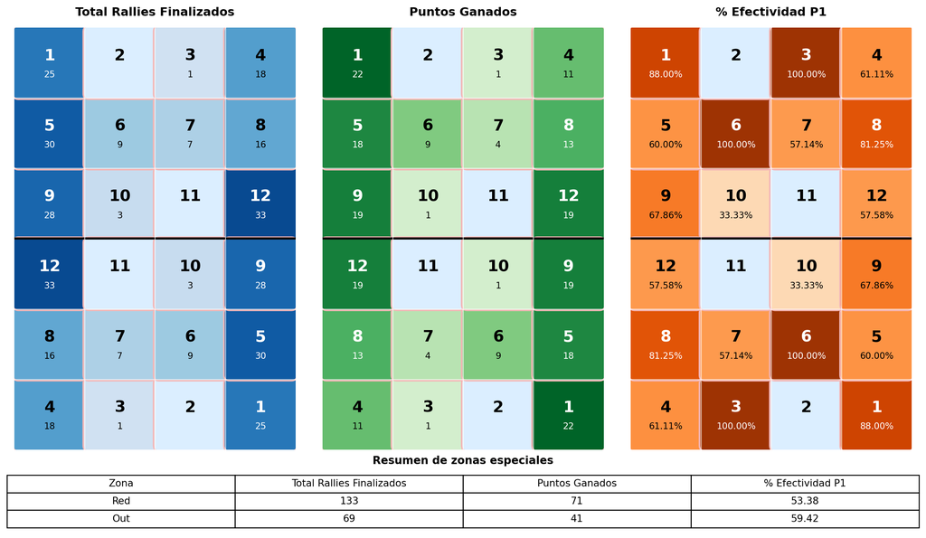

```python
def construir_matrices_metricas(resumen, columna_metricas):
    mapa_valores = {}
    for _, fila in resumen.iterrows():
        zona = fila['Zona']
        if isinstance(zona, (int, np.integer)):
            clave = int(zona)
        else:
            zona_txt = str(zona).strip()
            if zona_txt.isdigit():
                clave = int(zona_txt)
            else:
                continue
        mapa_valores[clave] = float(fila[columna_metricas])

    etiquetas_superior = [[9, 10, 11, 12], [5, 6, 7, 8], [1, 2, 3, 4]]
    etiquetas_inferior = [[4, 3, 2, 1], [8, 7, 6, 5], [12, 11, 10, 9]]

    valores_superior = np.array([[mapa_valores.get(z, np.nan) for z in fila] for fila in etiquetas_superior], dtype=float)
    valores_inferior = np.array([[mapa_valores.get(z, np.nan) for z in fila] for fila in etiquetas_inferior], dtype=float)

    return etiquetas_superior, etiquetas_inferior, valores_superior, valores_inferior


def dibujar_campograma_metricas(ax, etiquetas_superior, etiquetas_inferior, valores_superior, valores_inferior, titulo, formato_valor, cmap):
    ancho = 4
    alto_mitad = 3
    alto_total = 6
    color_fondo = '#dbeeff'
    color_borde = '#f4b6b6'

    ax.set_xlim(0, ancho)
    ax.set_ylim(0, alto_total)
    ax.set_aspect('equal')
    ax.axis('off')
    ax.set_title(titulo, fontsize=12, fontweight='bold', pad=12)

    valores = np.concatenate([valores_superior.ravel(), valores_inferior.ravel()])
    valores = valores[~np.isnan(valores)]
    if len(valores) > 0:
        minimo = float(valores.min())
        maximo = float(valores.max())
        normalizador = Normalize(vmin=minimo, vmax=maximo if maximo > minimo else minimo + 1)
    else:
        normalizador = None

    ax.add_patch(patches.Rectangle((0, 0), ancho, alto_total, facecolor=color_fondo, edgecolor='none'))
    ax.add_patch(patches.Rectangle((0, 0), ancho, alto_total, fill=False, edgecolor='gray', linewidth=1.8))
    ax.plot([0, ancho], [alto_mitad, alto_mitad], color='black', linewidth=2.2)

    zona_ancho = ancho / 4
    zona_alto = alto_mitad / 3

    def pintar_mitad(origen_y, etiquetas, valores_matriz):
        for fila in range(3):
            for columna in range(4):
                x = columna * zona_ancho
                y = origen_y + fila * zona_alto
                valor = valores_matriz[fila, columna]

                if normalizador is not None and not np.isnan(valor):
                    color_relleno = cmap(0.20 + 0.70 * normalizador(valor))
                else:
                    color_relleno = color_fondo

                zona = patches.FancyBboxPatch(
                    (x, y),
                    zona_ancho,
                    zona_alto,
                    boxstyle='round,pad=0.02,rounding_size=0.08',
                    facecolor=color_relleno,
                    edgecolor=color_borde,
                    linewidth=1.6,
                )
                ax.add_patch(zona)

                texto_color = 'white' if normalizador is not None and not np.isnan(valor) and normalizador(valor) > 0.55 else 'black'
                ax.text(
                    x + zona_ancho / 2,
                    y + zona_alto / 2 + 0.10,
                    str(etiquetas[fila][columna]),
                    ha='center',
                    va='center',
                    fontsize=16,
                    fontweight='bold',
                    color=texto_color,
                )
                if not np.isnan(valor):
                    ax.text(
                        x + zona_ancho / 2,
                        y + zona_alto / 2 - 0.17,
                        formato_valor(valor),
                        ha='center',
                        va='center',
                        fontsize=9,
                        color=texto_color,
                    )

    pintar_mitad(alto_mitad, etiquetas_superior, valores_superior)
    pintar_mitad(0, etiquetas_inferior, valores_inferior)

    for x in [1, 2, 3]:
        ax.plot([x, x], [0, alto_total], color='white', linewidth=1.1, alpha=0.6)

    for y in [1, 2, 4, 5]:
        ax.plot([0, ancho], [y, y], color='white', linewidth=1.1, alpha=0.6)


fig = plt.figure(figsize=(13, 7.5), constrained_layout=True)
gs = fig.add_gridspec(2, 3, height_ratios=[10, 1.4])

metricas = [
    ('Total Rallies Finalizados', 'Total Rallies Finalizados', plt.cm.Blues, lambda v: f'{v:.0f}'),
    ('Puntos Ganados', 'Puntos Ganados', plt.cm.Greens, lambda v: f'{v:.0f}'),
    ('% Efectividad P1', '% Efectividad P1', plt.cm.Oranges, lambda v: f'{v:.2f}%'),
]

for indice, (titulo, columna_metricas, cmap, formato_valor) in enumerate(metricas):
    ax = fig.add_subplot(gs[0, indice])
    etiquetas_superior, etiquetas_inferior, valores_superior, valores_inferior = construir_matrices_metricas(
        analisis_zonas,
        columna_metricas,
    )
    dibujar_campograma_metricas(
        ax,
        etiquetas_superior,
        etiquetas_inferior,
        valores_superior,
        valores_inferior,
        titulo,
        formato_valor,
        cmap,
    )

ax_tabla = fig.add_subplot(gs[1, :])
ax_tabla.axis('off')

zonas_especiales = analisis_zonas[analisis_zonas['Zona'].isin(['Red', 'Out'])].copy()
if not zonas_especiales.empty:
    zonas_especiales = zonas_especiales[['Zona', 'Total Rallies Finalizados', 'Puntos Ganados', '% Efectividad P1']]
    tabla = ax_tabla.table(
        cellText=zonas_especiales.values,
        colLabels=zonas_especiales.columns,
        cellLoc='center',
        loc='center',
    )
    tabla.auto_set_font_size(False)
    tabla.set_fontsize(10)
    tabla.scale(1, 1.15)
    ax_tabla.set_title('Resumen de zonas especiales', fontsize=11, fontweight='bold', pad=8)
else:
    ax_tabla.text(0.5, 0.5, 'No se encontraron filas para Red / Out en analisis_zonas.', ha='center', va='center')

plt.show()
```

# 6 Secuencias de golpeo

Conociendo ya las frecuencias de las zonas de golpeo, se da un paso más para estudiar las secuencias de golpeo. En otras palabras, se observan las zonas desde donde se golpea el volante cada vez hasta que este toca el suelo, la red o va fuera de la pista.

Para ello se muestra una tabla en la que se presentan las secuencias de golpeo de cada rally por partido y set.

**Código**

```python
def procesar_secuencias_badminton_partido(df):
    df = datos_badminton.copy() # Hacer una copia para no alterar el original
    # 1. Limpieza
    df['Zone'] = df['Zone'].astype(str).str.strip()

    # 2. El ID de secuencia debe cambiar si cambia el Partido, el Set O el Rally
    cambio_contexto = (df['Match'] != df['Match'].shift()) | \
                      (df['Set'] != df['Set'].shift()) | \
                      (df['Rally'] != df['Rally'].shift())

    df['secuencia_id'] = cambio_contexto.cumsum()

    tabla = df.groupby(['Match', 'Set', 'Rally', 'secuencia_id'], sort=False).agg({
        'Zone': lambda x: ' -> '.join(x),
        'Stroke': max}).reset_index()

    # 3. Seleccionar columnas finales
    tabla = tabla[['Match', 'Set', 'Rally', 'Stroke', 'Zone']]
    tabla.columns = ['Partido', 'Set', 'Rally', 'Número de Golpes', 'Secuencia de Zonas']

    return tabla

resultado = procesar_secuencias_badminton_partido(datos_badminton)
show(resultado)
```

[figure not shown]

En esta tabla aparecen las secuencias de todos los rallies, independientemente de quién los ganara.

A continuación se presenta la misma información para todos los rallies, añadiendo una columna que indica si Carolina ganó el punto.

**Código**

```python
def analizar_puntos_jugadora1(df):
    df_temp = df.copy()

    # 1. Identificar el final de cada rally y el score en ese momento. Agrupar por Partido, Set y Rally para obtener el máximo score alcanzado
    puntos_por_rally = df_temp.groupby(['Match', 'Set', 'Rally'], sort=False).agg({
        'Player 1 Score': 'max',
        'Zone': lambda x: ' -> '.join(x.astype(str).str.strip()),
        'Stroke': 'max'
    }).reset_index()

    # 2. Calcular si el punto fue para la Jugadora 1.
    # Se compara el score actual con el del rally anterior (dentro del mismo set y partido). Se usa shift() para ver el score previo. Si aumentó, es punto ganado. Para el primer punto (0 a 1), el shift será NaN, así que se llena con 0.
    puntos_por_rally['Score_Previo'] = puntos_por_rally.groupby(['Match', 'Set'])['Player 1 Score'].shift(1).fillna(0)
    puntos_por_rally['Gana_Punto_J1'] = puntos_por_rally['Player 1 Score'] > puntos_por_rally['Score_Previo']

    # 3. Limpiar y renombrar sin perder ningún rally
    secuencias_rallies = puntos_por_rally[['Match', 'Set', 'Rally', 'Stroke', 'Zone', 'Gana_Punto_J1']].copy()
    secuencias_rallies.columns = ['Partido', 'Set', 'Rally', 'Número de Golpes', 'Secuencia de Zonas', 'Gana_Punto_J1']

    return secuencias_rallies

resultado_p1 = analizar_puntos_jugadora1(datos_badminton)
show(resultado_p1)
```

[figure not shown]

## 6.1 Estadísticas de secuencias de golpeo

Habiendo obtenido las secuencias en cada rally, se calcula cuáles son las longitudes de secuencia más frecuentes en todos los partidos y en cada partido.

**Código**

```python
frecuencia_longitudes = resultado['Número de Golpes'].value_counts().reset_index()
frecuencia_longitudes.columns = ['Número de Golpes', 'Frecuencia']

print("--- Longitudes más habituales en los partidos ---")
print(frecuencia_longitudes.head(10).to_string(index=False))
```

```
--- Longitudes más habituales en los partidos ---
 Número de Golpes  Frecuencia
                5          40
                6          39
                4          32
                7          31
               10          26
                9          25
                8          23
                3          23
               11          21
               14          14
```

**Código**

```python
frecuencia_longitudes_partido = resultado.groupby(['Partido'], sort=False)['Número de Golpes'].value_counts().reset_index()
frecuencia_longitudes_partido.columns = ['Partido', 'Número de Golpes', 'Frecuencia']
frecuencia_longitudes_partido = frecuencia_longitudes_partido.sort_values(by=['Partido', 'Frecuencia'],
    ascending=[True, False])

print("--- Longitudes más habituales en cada partido ---")
print(frecuencia_longitudes_partido.head(10).to_string(index=False))
```

```
--- Longitudes más habituales en cada partido ---
                 Partido  Número de Golpes  Frecuencia
Carolina Marin-Li Xuerui                 7           8
Carolina Marin-Li Xuerui                 5           7
Carolina Marin-Li Xuerui                 6           6
Carolina Marin-Li Xuerui                16           5
Carolina Marin-Li Xuerui                11           5
Carolina Marin-Li Xuerui                14           5
Carolina Marin-Li Xuerui                 9           4
Carolina Marin-Li Xuerui                 8           4
Carolina Marin-Li Xuerui                20           3
Carolina Marin-Li Xuerui                12           3
```

**Código**

```python
frecuencia_longitudes_rallies = resultado_p1['Número de Golpes'].value_counts().reset_index()
frecuencia_longitudes_rallies.columns = ['Número de Golpes', 'Frecuencia (Todos los rallies)']

print("--- Longitudes más habituales en todos los rallies ---")
print(frecuencia_longitudes_rallies.head(10).to_string(index=False))
```

```
--- Longitudes más habituales en todos los rallies ---
 Número de Golpes  Frecuencia (Todos los rallies)
                5                              40
                6                              39
                4                              32
                7                              31
               10                              26
                9                              25
                8                              23
                3                              23
               11                              21
               14                              14
```

**Código**

```python
frecuencia_longitudes_rallies_partido = resultado_p1.groupby(['Partido'], sort=False)['Número de Golpes'].value_counts().reset_index()
frecuencia_longitudes_rallies_partido.columns = ['Partido', 'Número de Golpes', 'Frecuencia (Todos los rallies)']
frecuencia_longitudes_rallies_partido = frecuencia_longitudes_rallies_partido.sort_values(by=['Partido', 'Frecuencia (Todos los rallies)'],
    ascending=[True, False])

print("--- Longitudes más habituales en cada partido ---")
print(frecuencia_longitudes_rallies_partido.head(10).to_string(index=False))
```

```
--- Longitudes más habituales en cada partido ---
                 Partido  Número de Golpes  Frecuencia (Todos los rallies)
Carolina Marin-Li Xuerui                 7                               8
Carolina Marin-Li Xuerui                 5                               7
Carolina Marin-Li Xuerui                 6                               6
Carolina Marin-Li Xuerui                16                               5
Carolina Marin-Li Xuerui                11                               5
Carolina Marin-Li Xuerui                14                               5
Carolina Marin-Li Xuerui                 9                               4
Carolina Marin-Li Xuerui                 8                               4
Carolina Marin-Li Xuerui                20                               3
Carolina Marin-Li Xuerui                12                               3
```

# 7 Extracción de patrones de longitud 3

Una vez analizadas algunas estadísticas sobre los golpes y las secuencias, se da un paso más para conocer cuáles son los patrones de longitud 3 (secuencias de 3 golpes) más frecuentes en los partidos.

## 7.1 Patrones de longitud 3 más frecuentes

El primer paso es extraer las secuencias de longitud 3 más frecuentes en todos los partidos y en cada partido. Con esto, se obtiene una visión general de los patrones de golpeo más habituales.

**Código**

```python
def extraer_patrones_longitud_3(df):
    df_temp = df.copy()
    df_temp = df_temp.sort_values(['Match', 'Set', 'Rally', 'Stroke'])

    # 1. Agrupar los golpes en cada rally manteniendo el orden temporal
    puntos_por_rally = df_temp.groupby(['Match', 'Set', 'Rally'], sort=False).agg({
        'Zone': lambda x: x.astype(str).str.strip().tolist(),
        'Stroke': 'max'
    }).reset_index()

    # 2. Extraer todas las ventanas deslizantes de 3 golpes dentro de cada rally
    def extraer_ventanas_3(zonas):
        if len(zonas) < 3:
            return []
        return [' -> '.join(zonas[i:i + 3]) for i in range(len(zonas) - 2)]

    puntos_por_rally['Patrón_3'] = puntos_por_rally['Zone'].apply(extraer_ventanas_3)
    puntos_por_rally = puntos_por_rally.explode('Patrón_3').dropna(subset=['Patrón_3'])

    # 3. Contar la frecuencia de cada patrón de longitud 3
    frecuencia_patrones = puntos_por_rally['Patrón_3'].value_counts().reset_index()
    frecuencia_patrones.columns = ['Patrón de Longitud 3', 'Frecuencia']

    return frecuencia_patrones

frecuencia_patrones_longitud_3 = extraer_patrones_longitud_3(datos_badminton)

print("--- Patrones de longitud 3 más frecuentes en todos los rallies ---")
print(frecuencia_patrones_longitud_3.head(10))
```

```
--- Patrones de longitud 3 más frecuentes en todos los rallies ---
  Patrón de Longitud 3  Frecuencia
0         4 -> 1 -> 12          57
1         12 -> 5 -> 4          56
2          9 -> 8 -> 1          37
3          5 -> 4 -> 1          36
4        12 -> 9 -> 12          34
5         1 -> 12 -> 5          34
6         1 -> 12 -> 9          33
7          1 -> 4 -> 9          32
8         1 -> 4 -> 12          32
9          4 -> 9 -> 8          31
```

## 7.2 Comparación de patrones de longitud 3 entre Carolina Marín y sus rivales

A continuación se comparan los patrones de longitud 3 más frecuentes entre Carolina Marín y sus rivales usando todos los rallies.

En la siguiente gráfica se muestran los patrones de longitud 3 más frecuentes para Carolina Marín y para sus rivales en todos los rallies. Se pueden observar cuáles son los patrones más habituales para cada jugadora y comparar su frecuencia.

**Código**

```
--- Tabla de patrones (todos los rallies) desglosada por jugadora ---
```

[figure not shown]

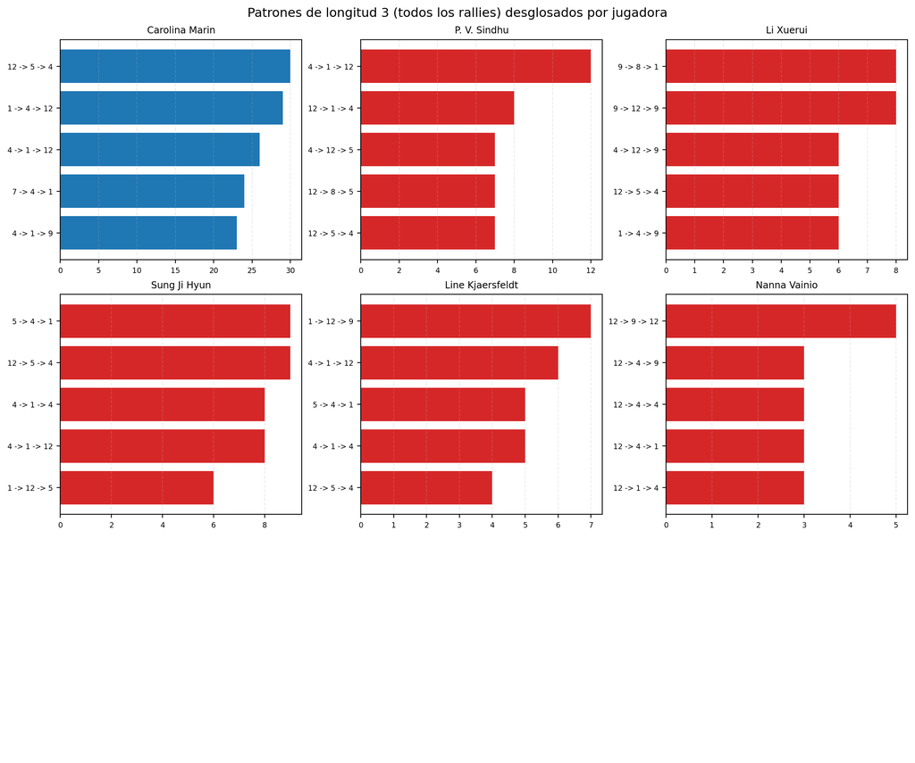

```python
def extraer_patrones_todos_desglose_jugadora(df):
    df_temp = df.copy().sort_values(['Match', 'Set', 'Rally', 'Stroke'])
    nombre_carolina = df_temp['Player1'].iloc[0]

    puntos_por_rally = df_temp.groupby(['Match', 'Set', 'Rally'], sort=False).agg({
        'Zone': lambda x: x.astype(str).str.strip().tolist(),
        'Jugador del golpeo': lambda x: x.astype(str).str.strip().tolist()
    }).reset_index()

    registros = []
    for _, fila in puntos_por_rally.iterrows():
        zonas = fila['Zone']
        jugadoras = fila['Jugador del golpeo']

        if len(zonas) < 3:
            continue

        for i in range(len(zonas) - 2):
            patron = ' -> '.join(zonas[i:i + 3])
            jugadora_patron = jugadoras[i + 2]
            registros.append({'Jugadora': jugadora_patron, 'Patrón de Longitud 3': patron})

    patrones_df = pd.DataFrame(registros)
    frecuencia = patrones_df.groupby(['Jugadora', 'Patrón de Longitud 3']).size().reset_index(name='Frecuencia')
    return frecuencia, nombre_carolina


frecuencia_todos_jugadoras, nombre_carolina = extraer_patrones_todos_desglose_jugadora(datos_badminton)

# Tabla top 5 por jugadora (Carolina + hasta 8 rivales con mayor frecuencia total)
top_rivales_todos_j = (
    frecuencia_todos_jugadoras[frecuencia_todos_jugadoras['Jugadora'] != nombre_carolina]
    .groupby('Jugadora', as_index=False)['Frecuencia'].sum()
    .sort_values('Frecuencia', ascending=False)
)
jugadoras_plot_todos = [nombre_carolina] + top_rivales_todos_j['Jugadora'].head(8).tolist()

tabla_top_todos = []
for jugadora in jugadoras_plot_todos:
    top_j = frecuencia_todos_jugadoras[frecuencia_todos_jugadoras['Jugadora'] == jugadora].nlargest(5, 'Frecuencia').copy()
    top_j['Ranking'] = range(1, len(top_j) + 1)
    tabla_top_todos.append(top_j[['Jugadora', 'Ranking', 'Patrón de Longitud 3', 'Frecuencia']])

tabla_top_todos = pd.concat(tabla_top_todos, ignore_index=True)
print('--- Tabla de patrones (todos los rallies) desglosada por jugadora ---')
show(tabla_top_todos)

# Gráficas pequeñas 3x3 (todos los rallies, desglosado por jugadora)
fig, axes = plt.subplots(3, 3, figsize=(12, 10), constrained_layout=True)
axes = axes.flatten()

for idx, jugadora in enumerate(jugadoras_plot_todos[:9]):
    ax = axes[idx]
    datos_j = frecuencia_todos_jugadoras[frecuencia_todos_jugadoras['Jugadora'] == jugadora].nlargest(5, 'Frecuencia').copy()

    if datos_j.empty:
        ax.axis('off')
        continue

    datos_j = datos_j.sort_values('Frecuencia', ascending=True)
    color = '#1f77b4' if jugadora == nombre_carolina else '#d62728'

    ax.barh(datos_j['Patrón de Longitud 3'], datos_j['Frecuencia'], color=color)
    ax.set_title(jugadora, fontsize=9)
    ax.tick_params(axis='y', labelsize=7)
    ax.tick_params(axis='x', labelsize=7)
    ax.grid(axis='x', linestyle='--', alpha=0.25)

for idx in range(len(jugadoras_plot_todos[:9]), 9):
    axes[idx].axis('off')

fig.suptitle('Patrones de longitud 3 (todos los rallies) desglosados por jugadora', fontsize=12)
plt.show()
```

En el siguiente apartado, mediante cadenas de Markov, se analizará la probabilidad de ganar un punto a partir de los patrones de golpeo. Para ello, se construirá una matriz de transición entre las zonas de golpeo y se calculará la probabilidad de ganar el punto para cada patrón. Con ello se podrá conocer cuáles son los patrones de golpeo que más probabilidades tienen de llevar a la consecución del punto para Carolina Marín.

# 8 Cadenas de Markov para analizar la probabilidad de ganar un punto a partir de los patrones de golpeo

En este último apartado, se construirá una matriz de transición entre las zonas de golpeo y se calculará la probabilidad de ganar el punto para cada patrón. Con ello se podrá conocer cuáles son los patrones de golpeo que más probabilidades tienen de llevar a la consecución de ganar un punto.

# 9 Cadenas de Markov

Una cadena de Markov es un modelo matemático que describe un sistema que cambia de estado de manera probabilística. En este contexto, cada “estado” representa un patrón (secuencia de 3 golpes) y las transiciones entre estados representan la probabilidad de pasar de un patrón a otro en el siguiente golpe. Los pasos para implementar una cadena de Markov en este análisis son:

1. **Definir los estados**: Cada patrón de longitud 3 se considerará un estado en la cadena de Markov. Que el punto se termine ganando o perdiendo se considerará un **estado absorbente**, es decir, un estado que una vez alcanzado no se sale de él.
2. **Construir la matriz de transición**: Se calculará la frecuencia con la que se pasa de un patrón a otro en los rallies, lo que permitirá construir una matriz de transición que refleje estas probabilidades.

## 9.1 Construcción de la matriz de transición

Para construir la matriz de transición se sigue el siguiente procedimiento técnico:

1. Se transforma cada rally en una secuencia de estados, donde cada estado es un patrón de 3 zonas consecutivas.
2. Se filtran solo los patrones cuyo tercer golpe lo ejecuta Carolina Marín.
3. Se cuentan transiciones entre esos patrones consecutivos de Carolina dentro del rally.
4. Desde el último patrón de Carolina en cada rally se añade una transición al estado absorbente `GANA_PUNTO` o `PIERDE_PUNTO` (desde la perspectiva de Carolina).
5. Se normalizan filas para obtener probabilidades de transición y construir la matriz $P$.
6. Se reordena $P$ en forma canónica para cadenas absorbentes:

$$P = \begin{pmatrix}
Q & R \\
0 & I
\end{pmatrix}$$

7. Se calcula la matriz fundamental $N=(I-Q)^{-1}$ y la matriz de absorción:

$$B = N\,R$$

donde cada fila de $B$ devuelve la probabilidad de acabar en `GANA_PUNTO` o `PIERDE_PUNTO` partiendo de un patrón concreto.

**Código**

```python
def construir_modelo_markov_patrones(df):
    df_temp = df.copy().sort_values(['Match', 'Set', 'Rally', 'Stroke'])
    nombre_carolina = df_temp['Player1'].iloc[0]

    # 1) Secuencias por rally y resultado del punto para Carolina
    rallys = df_temp.groupby(['Match', 'Set', 'Rally'], sort=False).agg({
        'Zone': lambda x: x.astype(str).str.strip().tolist(),
        'Jugador del golpeo': lambda x: x.astype(str).str.strip().tolist(),
        'Player 1 Score': 'max'
    }).reset_index()

    rallys['Score_Previo'] = rallys.groupby(['Match', 'Set'])['Player 1 Score'].shift(1).fillna(0)
    rallys['Gana_P1'] = rallys['Player 1 Score'] > rallys['Score_Previo']

    # 2) Construcción de transiciones entre patrones y hacia estados absorbentes
    transiciones = []
    visitas_patron = []

    for _, fila in rallys.iterrows():
        zonas = fila['Zone']
        jugadoras = fila['Jugador del golpeo']
        gana_p1 = bool(fila['Gana_P1'])

        if len(zonas) < 3:
            continue

        # Patrones de longitud 3 y jugadora que ejecuta el 3er golpe
        patrones_carolina = []
        for i in range(len(zonas) - 2):
            patron = ' -> '.join(zonas[i:i + 3])
            jugadora_tercer_golpe = jugadoras[i + 2]
            if jugadora_tercer_golpe == nombre_carolina:
                patrones_carolina.append(patron)

        if len(patrones_carolina) == 0:
            continue

        visitas_patron.extend(patrones_carolina)

        # Transiciones entre patrones consecutivos de Carolina dentro del mismo rally
        for i in range(len(patrones_carolina) - 1):
            transiciones.append((patrones_carolina[i], patrones_carolina[i + 1]))

        # Transición absorbente desde el último patrón de Carolina del rally
        estado_absorbente = 'GANA_PUNTO' if gana_p1 else 'PIERDE_PUNTO'
        transiciones.append((patrones_carolina[-1], estado_absorbente))

    # 3) Frecuencias de transiciones
    trans_df = pd.DataFrame(transiciones, columns=['origen', 'destino'])
    conteo_trans = trans_df.groupby(['origen', 'destino']).size().reset_index(name='Frecuencia')

    estados_transitorios = sorted(set(conteo_trans['origen']))
    estados_absorbentes = ['GANA_PUNTO', 'PIERDE_PUNTO']
    estados_transitorios = [e for e in estados_transitorios if e not in estados_absorbentes]
    estados = estados_transitorios + estados_absorbentes

    # 4) Matriz de conteos y normalización a probabilidades
    matriz_conteo = pd.DataFrame(0.0, index=estados, columns=estados)
    for _, r in conteo_trans.iterrows():
        matriz_conteo.loc[r['origen'], r['destino']] = r['Frecuencia']

    for ea in estados_absorbentes:
        matriz_conteo.loc[ea, ea] = 1.0

    suma_filas = matriz_conteo.sum(axis=1)
    matriz_P = matriz_conteo.div(suma_filas.replace(0, np.nan), axis=0).fillna(0)

    # 5) Forma canónica absorbente
    t = len(estados_transitorios)
    Q = matriz_P.iloc[:t, :t].values
    R = matriz_P.iloc[:t, t:].values

    I = np.eye(t)
    N = np.linalg.inv(I - Q)
    B = N @ R

    prob_abs = pd.DataFrame(
        B,
        index=estados_transitorios,
        columns=['Prob_Ganar', 'Prob_Perder']
    ).reset_index().rename(columns={'index': 'Patrón'})

    # Frecuencia de visitas por patrón para filtrar ruido
    visitas_df = pd.Series(visitas_patron).value_counts().reset_index()
    visitas_df.columns = ['Patrón', 'Visitas']
    prob_abs = prob_abs.merge(visitas_df, on='Patrón', how='left').fillna({'Visitas': 0})
    prob_abs['Visitas'] = prob_abs['Visitas'].astype(int)

    return {
        'P': matriz_P,
        'Q': Q,
        'R': R,
        'N': N,
        'B': B,
        'prob_abs': prob_abs,
        'estados_transitorios': estados_transitorios,
        'estados_absorbentes': estados_absorbentes
    }


modelo_markov = construir_modelo_markov_patrones(datos_badminton)

print('--- Dimensiones del modelo ---')
print(f"Estados transitorios: {len(modelo_markov['estados_transitorios'])}")
print(f"Estados absorbentes: {len(modelo_markov['estados_absorbentes'])}")
print(f"Matriz P: {modelo_markov['P'].shape[0]} x {modelo_markov['P'].shape[1]}")

print('\n--- Submatriz de transición (primeros 10 estados) ---')
idx_filas = list(modelo_markov['P'].index[:4]) + list(modelo_markov['P'].index[-4:])
idx_cols = list(modelo_markov['P'].columns[:4]) + list(modelo_markov['P'].columns[-4:])
submatriz_resumen = modelo_markov['P'].loc[idx_filas, idx_cols]
print('\n--- Submatriz de transición (4 primeros y 4 últimos estados) ---')
show(submatriz_resumen.round(3))
```

```
--- Dimensiones del modelo ---
Estados transitorios: 472
Estados absorbentes: 2
Matriz P: 474 x 474

--- Submatriz de transición (primeros 10 estados) ---

--- Submatriz de transición (4 primeros y 4 últimos estados) ---
```

[figure not shown]

# 10 Probabilidad de ganar el punto para cada patrón

Con la matriz $B=N\,R$ se obtiene directamente la probabilidad de absorción en `GANA_PUNTO` o `PIERDE_PUNTO` desde cada patrón de longitud 3.

**Código**

```python
resultado_markov = modelo_markov['prob_abs'].copy()

# Filtro de soporte mínimo para evitar patrones extremadamente raros
resultado_filtrado = resultado_markov[resultado_markov['Visitas'] >= 5].copy()

top_ganar = resultado_filtrado.sort_values(['Prob_Ganar', 'Visitas'], ascending=[False, False]).head(10)
top_perder = resultado_filtrado.sort_values(['Prob_Perder', 'Visitas'], ascending=[False, False]).head(10)

print('--- Patrones con mayor probabilidad de GANAR (Carolina) ---')
show(top_ganar[['Patrón', 'Visitas', 'Prob_Ganar', 'Prob_Perder']].round(4))

print('--- Patrones con mayor probabilidad de PERDER (Carolina) ---')
show(top_perder[['Patrón', 'Visitas', 'Prob_Ganar', 'Prob_Perder']].round(4))
```

```
--- Patrones con mayor probabilidad de GANAR (Carolina) ---
```

[figure not shown]

```
--- Patrones con mayor probabilidad de PERDER (Carolina) ---
```

[figure not shown]

**Código**

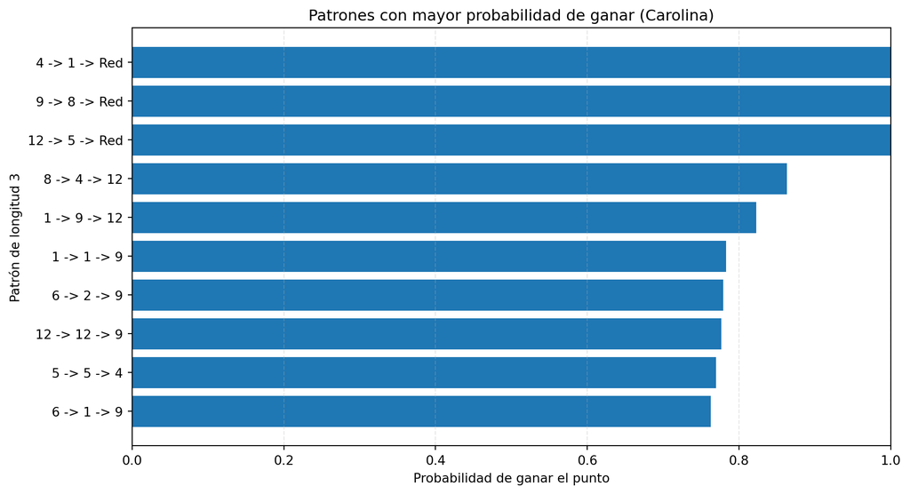

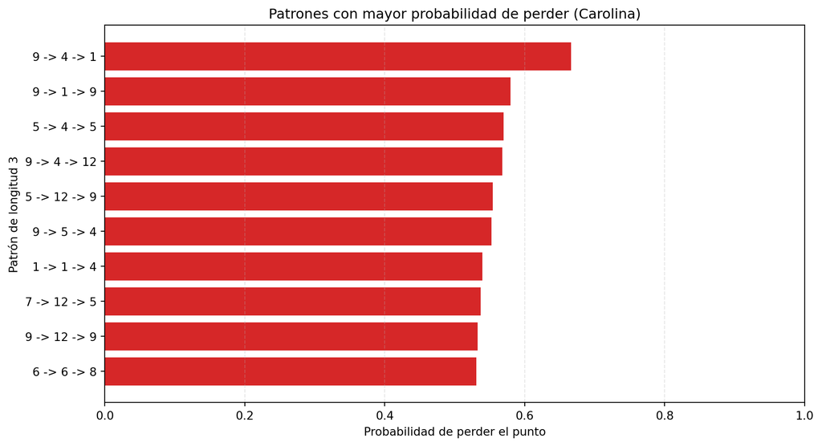

```python
# Gráfica 1: Top patrones con mayor probabilidad de ganar
datos_plot_ganar = top_ganar.sort_values('Prob_Ganar', ascending=True)

plt.figure(figsize=(10, 5.5))
plt.barh(datos_plot_ganar['Patrón'], datos_plot_ganar['Prob_Ganar'], color='#1f77b4')
plt.xlabel('Probabilidad de ganar el punto')
plt.ylabel('Patrón de longitud 3')
plt.title('Patrones con mayor probabilidad de ganar (Carolina)')
plt.xlim(0, 1)
plt.grid(axis='x', linestyle='--', alpha=0.3)
plt.tight_layout()
plt.show()

# Gráfica 2: Top patrones con mayor probabilidad de perder
datos_plot_perder = top_perder.sort_values('Prob_Perder', ascending=True)

plt.figure(figsize=(10, 5.5))
plt.barh(datos_plot_perder['Patrón'], datos_plot_perder['Prob_Perder'], color='#d62728')
plt.xlabel('Probabilidad de perder el punto')
plt.ylabel('Patrón de longitud 3')
plt.title('Patrones con mayor probabilidad de perder (Carolina)')
plt.xlim(0, 1)
plt.grid(axis='x', linestyle='--', alpha=0.3)
plt.tight_layout()
plt.show()
```